# Diamonds quality

In this data challenge we explore the qualities of diamonds and their association with price using the `ggplot2::diamonds` dataset:

1. First of all, observe that low quality diamonds (with respect to cut, color and clarity) are more expensive.
2. Using models, find an explanation and solve the apparent paradox.

Recall that:

- best cut is Ideal, worst is Fair
- best color is D, worst is J
- best clarity is IF, worst is I1

```r
library(ggplot2)
library(dplyr)

diamonds
```

```
## # A tibble: 53,940 × 10
##    carat cut       color clarity depth table price     x     y     z
##    <dbl> <ord>     <ord> <ord>   <dbl> <dbl> <int> <dbl> <dbl> <dbl>
##  1  0.23 Ideal     E     SI2      61.5    55   326  3.95  3.98  2.43
##  2  0.21 Premium   E     SI1      59.8    61   326  3.89  3.84  2.31
##  3  0.23 Good      E     VS1      56.9    65   327  4.05  4.07  2.31
##  4  0.29 Premium   I     VS2      62.4    58   334  4.2   4.23  2.63
##  5  0.31 Good      J     SI2      63.3    58   335  4.34  4.35  2.75
##  6  0.24 Very Good J     VVS2     62.8    57   336  3.94  3.96  2.48
##  7  0.24 Very Good I     VVS1     62.3    57   336  3.95  3.98  2.47
##  8  0.26 Very Good H     SI1      61.9    55   337  4.07  4.11  2.53
##  9  0.22 Fair      E     VS2      65.1    61   337  3.87  3.78  2.49
## 10  0.23 Very Good H     VS1      59.4    61   338  4     4.05  2.39
## # ℹ 53,930 more rows
```

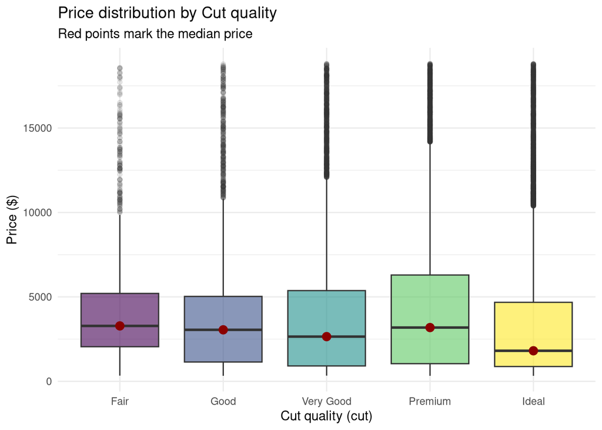

```r
ggplot(diamonds, aes(x = cut, y = price, fill = cut)) +
  geom_boxplot(alpha = 0.6, outlier.alpha = 0.1) +
  stat_summary(fun = median, geom = "point", color = "darkred", size = 3) +
  labs(
    title = "Price distribution by Cut quality",
    subtitle = "Red points mark the median price",
    x = "Cut quality (cut)",
    y = "Price ($)"
  ) +
  theme_minimal() +
  theme(legend.position = "none")
```

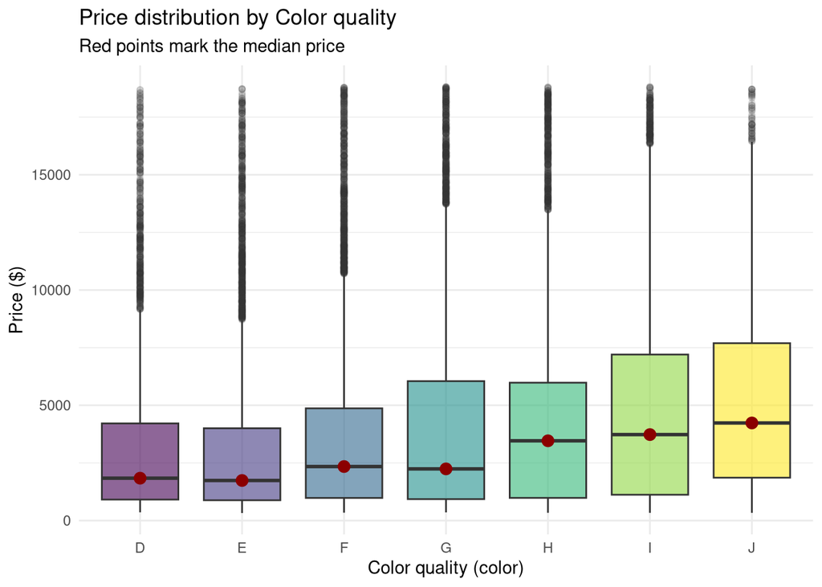

```r
ggplot(diamonds, aes(x = color, y = price, fill = color)) +
  geom_boxplot(alpha = 0.6, outlier.alpha = 0.1) +
  stat_summary(fun = median, geom = "point", color = "darkred", size = 3) +
  labs(
    title = "Price distribution by Color quality",
    subtitle = "Red points mark the median price",
    x = "Color quality (color)",
    y = "Price ($)"
  ) +
  theme_minimal() +
  theme(legend.position = "none")
```

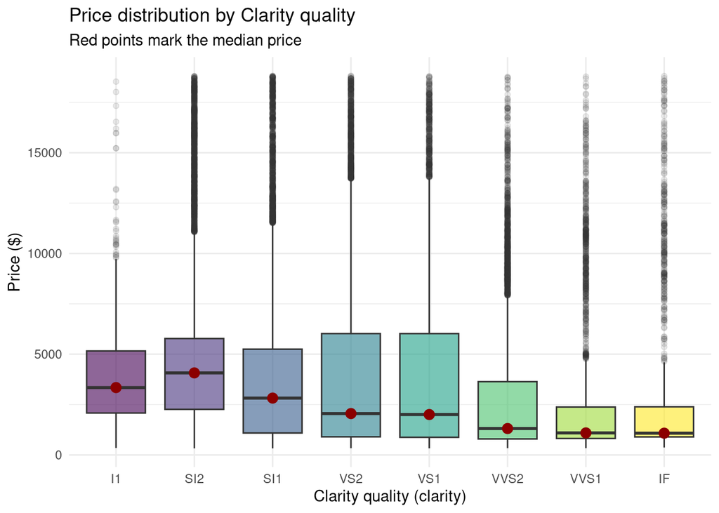

```r
ggplot(diamonds, aes(x = clarity, y = price, fill = clarity)) +
  geom_boxplot(alpha = 0.6, outlier.alpha = 0.1) +
  stat_summary(fun = median, geom = "point", color = "darkred", size = 3) +
  labs(
    title = "Price distribution by Clarity quality",
    subtitle = "Red points mark the median price",
    x = "Clarity quality (clarity)",
    y = "Price ($)"
  ) +
  theme_minimal() +
  theme(legend.position = "none")
```

For all three variables the cheaper diamonds are often the better ones. Ideal diamonds have a lower median price than Fair ones, color J (the worst) is more expensive than D (the best), and clarity IF (the best) is among the cheapest. The median price of clarity I1 (the worst) is about 3300 while IF has about 1100. Something else must drive the price. A natural candidate is the weight of the diamond, `carat`: the table below shows the average price and carat for each cut.

```r
diamonds |>
  group_by(cut) |>
  summarise(
    mean_price = mean(price),
    mean_carat = mean(carat),
    mean_clarity = mean(as.integer(clarity))
  )
```

```
## # A tibble: 5 × 4
##   cut       mean_price mean_carat mean_clarity
##   <ord>          <dbl>      <dbl>        <dbl>
## 1 Fair           4359.      1.05          3.02
## 2 Good           3929.      0.849         3.60
## 3 Very Good      3982.      0.806         4.00
## 4 Premium        4584.      0.892         3.74
## 5 Ideal          3458.      0.703         4.46
```

The pattern is the same: Fair diamonds are on average the heaviest (1.05 carat) and Ideal ones the lightest (0.70 carat), and the price follows the weight. Bigger diamonds are rarer and more expensive, but they are also harder to cut well, so they tend to have a worse cut, color and clarity. This is a confounding effect: quality looks negatively associated with price only because it is negatively associated with carat.

### 2.

To remove the effect of the weight we compare diamonds that weigh about the same: we keep only the ones between 0.9 and 1.1 carat (about 10000 diamonds) and look again at the price for each quality.

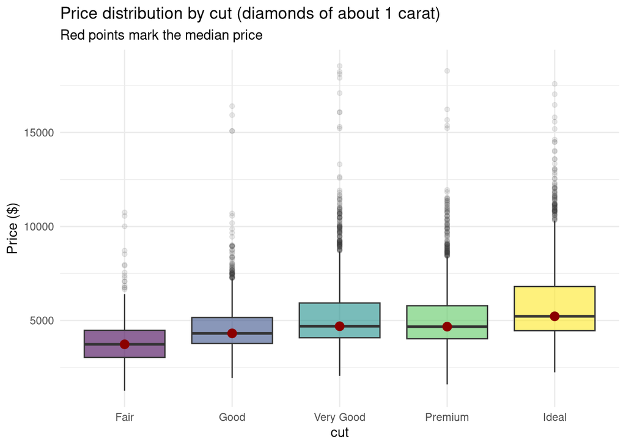

```r
diamonds_1ct <- diamonds |>
  filter(carat >= 0.9, carat <= 1.1)

plot_price_by <- function(variable) {
  ggplot(diamonds_1ct, aes(x = .data[[variable]], y = price, fill = .data[[variable]])) +
    geom_boxplot(alpha = 0.6, outlier.alpha = 0.1) +
    stat_summary(fun = median, geom = "point", color = "darkred", size = 3) +
    labs(
      title = paste("Price distribution by", variable, "(diamonds of about 1 carat)"),
      subtitle = "Red points mark the median price",
      x = variable,
      y = "Price ($)"
    ) +
    theme_minimal() +
    theme(legend.position = "none")
}

plot_price_by("cut")
```

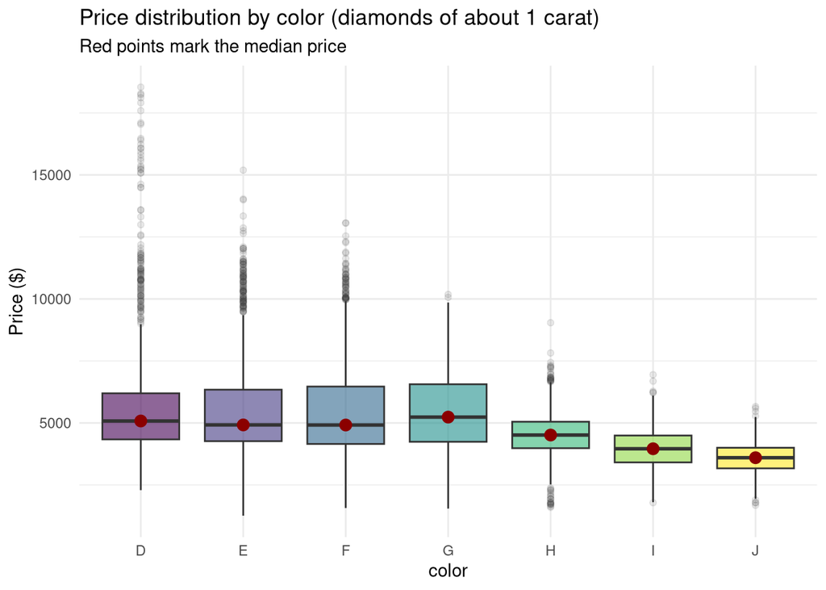

```r
plot_price_by("color")
```

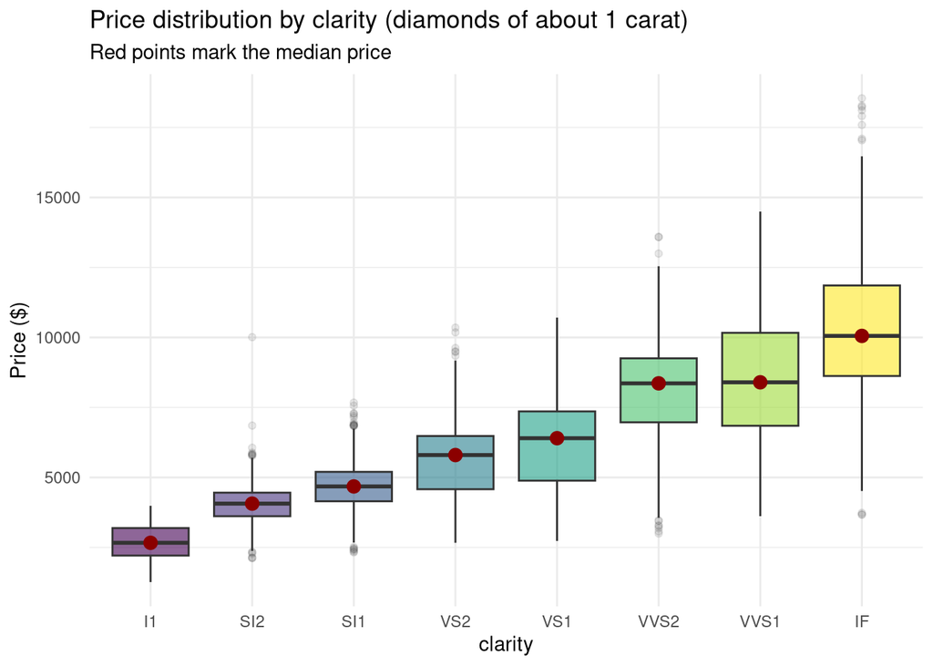

```r
plot_price_by("clarity")
```

At the same weight the paradox disappears: the median price grows with the quality. Ideal diamonds cost more than Fair ones (5220 against 3730), clarity IF costs about four times I1 (10056 against 2666) and the colors D to G (about 5000) cost more than J (3600). The cut and the color have a weaker effect than the clarity, and the order is not perfect (for example Premium and Very Good are almost equal, and color D is not above G), but the trend is now the expected one. The weight is therefore the confounding variable: low quality diamonds looked more expensive only because they are bigger, and a bigger diamond costs much more.

#### Using models

The same conclusion can be reached with a model, which uses all the diamonds instead of only the ones of about 1 carat.

We fit a model for the log of the price (price grows roughly exponentially with size, and the log makes the relation linear) using only the quality variables. The coefficients are the differences with respect to the worst level (Fair, J, I1).

```r
diamonds_f <- diamonds |>
  mutate(
    cut = relevel(factor(cut, ordered = FALSE), "Fair"),
    color = relevel(factor(color, ordered = FALSE), "J"),
    clarity = relevel(factor(clarity, ordered = FALSE), "I1")
  )

model_quality <- lm(log(price) ~ cut + color + clarity, data = diamonds_f)
round(coef(model_quality), 2)
```

```
##  (Intercept)      cutGood cutVery Good   cutPremium     cutIdeal       colorD
##         8.41        -0.16        -0.16        -0.06        -0.26        -0.52
##       colorE       colorF       colorG       colorH       colorI   claritySI2
##        -0.53        -0.33        -0.26        -0.20        -0.09         0.23
##   claritySI1   clarityVS2   clarityVS1  clarityVVS2  clarityVVS1    clarityIF
##        -0.08        -0.15        -0.22        -0.36        -0.58        -0.51
```

```r
summary(model_quality)$r.squared
```

```
## [1] 0.08483368
```

Without `carat` the model reproduces the paradox: the coefficients of the best cut (Ideal, -0.26) and of the best colors (D and E, about -0.5) are negative, meaning cheaper than the worst level. Also, the model explains only 8% of the variability of the price. Now we add `carat`, also on log scale:

```r
model_carat <- lm(log(price) ~ log(carat) + cut + color + clarity, data = diamonds_f)
round(coef(model_carat), 2)
```

```
##  (Intercept)   log(carat)      cutGood cutVery Good   cutPremium     cutIdeal
##         7.35         1.88         0.08         0.12         0.14         0.16
##       colorD       colorE       colorF       colorG       colorH       colorI
##         0.51         0.46         0.42         0.35         0.26         0.14
##   claritySI2   claritySI1   clarityVS2   clarityVS1  clarityVVS2  clarityVVS1
##         0.43         0.59         0.74         0.81         0.95         1.02
##    clarityIF
##         1.11
```

```r
summary(model_carat)$r.squared
```

```
## [1] 0.9826161
```

Once the weight is taken into account the paradox disappears, and the model explains 98% of the variability. All the quality coefficients now have the expected sign and grow with quality: Ideal is about 17% more expensive than Fair (`exp(0.16)`) with the same carat, color D is about 67% more expensive than J (`exp(0.51)`) and clarity IF about three times more expensive than I1 (`exp(1.11)`). The coefficient of `log(carat)` is 1.88: a 1% heavier diamond is about 1.9% more expensive. So, at equal weight, better quality means higher price. Low quality diamonds looked more expensive only because they are bigger.